# Statistisk inferensteori Likelihood (H & B, Kapitel 1-2)

## Tre exempel

## Statistisk kvalitetskontroll

En industri producerar komponenter i stor volym, istället för att kontrollera samtliga komponenter i en batch om \(1000\) st gör man ett slumpmässigt stickprov av \(50\) st. Av dessa visar sig \(3\) vara defekta.

Är kvalitetsmålet max 10% defekta uppfyllt?

## Livslängder

Figuren beskriver tidpunkter för fel (i flygtimmar efter mätningar började) hos luftkonditionering i en Boeing 720.

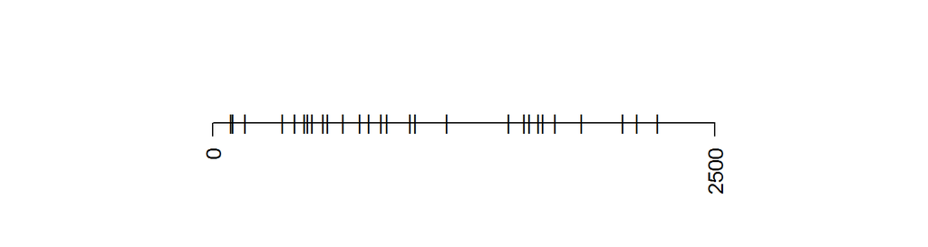

Hur stor är felintensiteten?

## Trädvolymer

Hur kan vi prediktera volym givet radie och höjd?

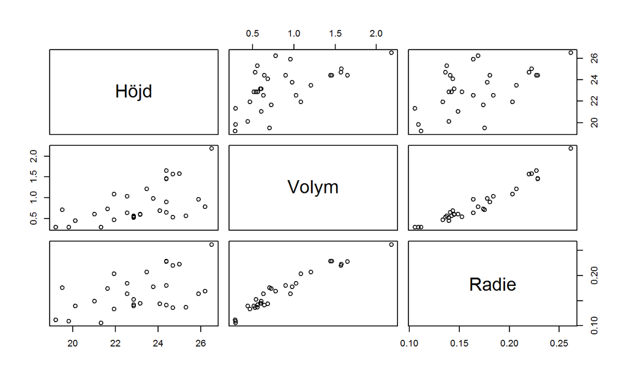

## Statistiska modeller

[figure not shown]

*Essentially all models are wrong, but some are useful.*

– George E. P. Box

## Statistisk modell

**Definition:** (H & B, sekt. 1.2) En statistisk modell är en familj av sannolikhetsfördelningar \(\mathcal{P}=\{P_\theta, \theta\in\Theta \}\) definierade på utfallsrummet \(\mathcal{T}\).

**Definition:** En statistisk modell \(\mathcal{P}=\{P_\theta, \theta\in\Theta \}\) är identifierbar om \(P_{\theta_1}=P_{\theta_2}\Rightarrow \theta_1=\theta_2\) för alla \(\theta_1\) och \(\theta_2\) i \(\Theta\).

## Likelihood

## Likelihood

**Definition:** (H & B, def. 2.1) Givet observerad data \(x\in \mathcal{T}\) och en modell \(\mathcal{P}=\{P_\theta; \theta\in\Theta\}\) ges likelihoodfunktionen av \[L(\theta)=p(x|\theta),\quad \theta\in\Theta,\] där \(p(\cdot|\theta)\) är den täthet/sannolikhetsfunktion som svarar mot \(P_\theta\). Log-likelihoodfunktionen är \[l(\theta)=\log L(\theta),\quad \theta\in\Theta.\]

## Statistisk kvalitetskontroll

Antag \(N=1000, n=50\) och att vi finner \(x=3\) defekta.

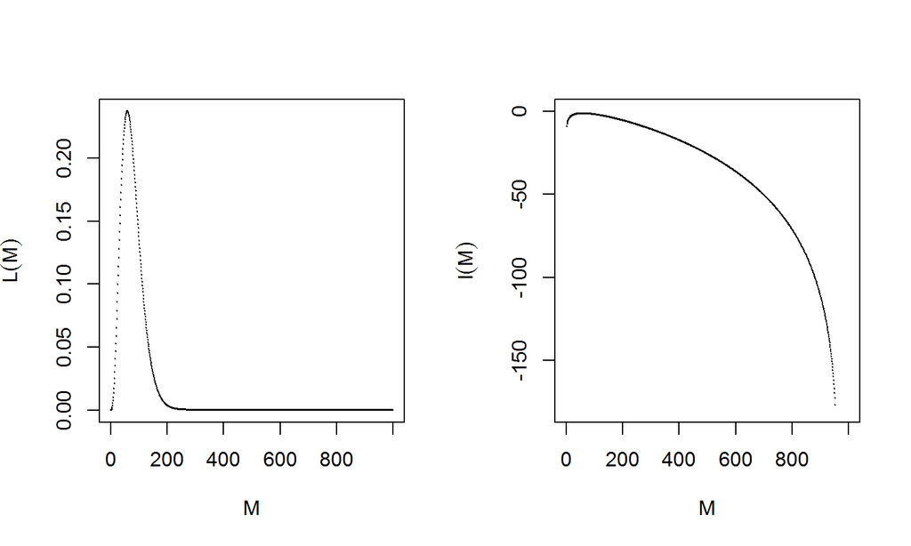

## Statistisk kvalitetskontroll (Binomial)

Antag \(n=50\) och att vi finner \(x=3\) defekta.

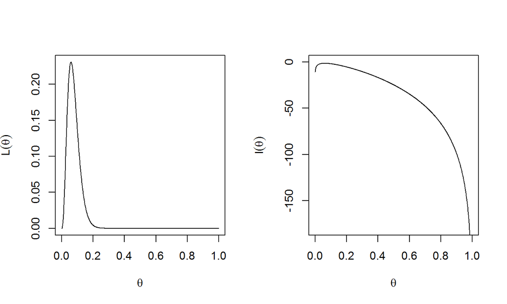

## Livslängder

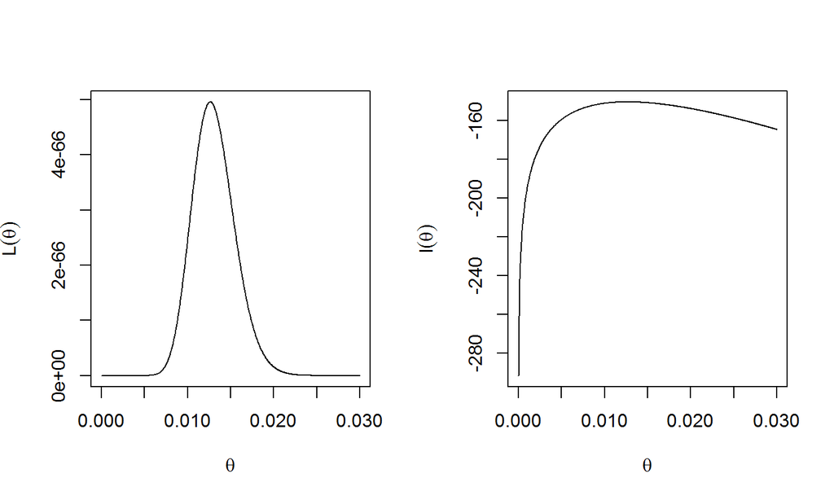

## Trädvolymer

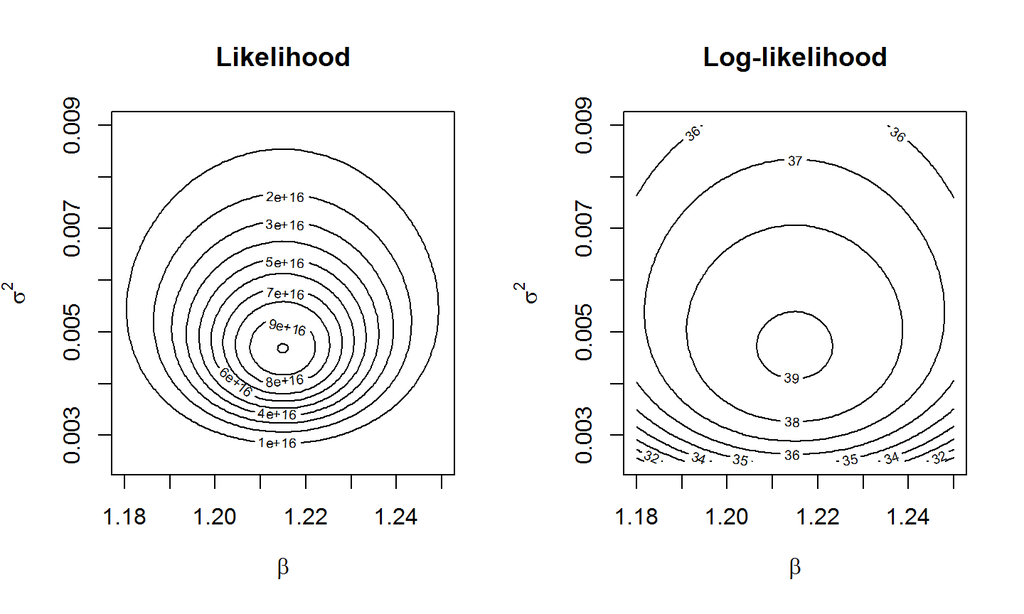

## Maximum likelihood

**Definition:** (H & B, def. 2.2) En maximum-likelihood skattning av \(\theta_0\) är ett värde \(\hat{\theta}\in\Theta\) som maximerar \(L(\theta)\).

## Binomialfördelning likelihood då \(x=n\)

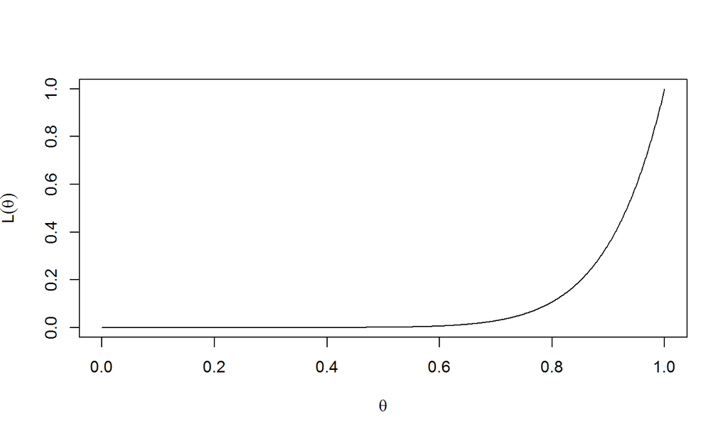

## Laplacefördelning täthet (\(\theta=1\))

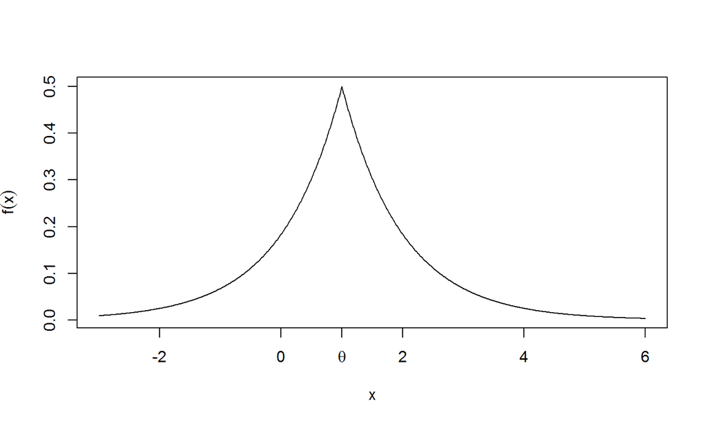

## Laplacefördelning likelihood

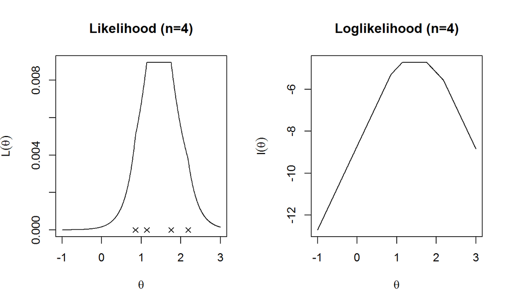

## Laplacefördelning likelihood

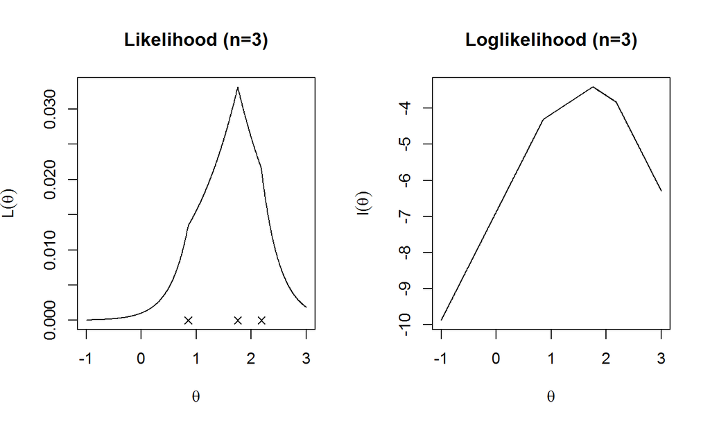

## Transformationer av data

## Likelihood och transformationer av data

**Sats:** (Transformationssatsen Gut, Th. 2.1 eller H & B (A.12)) Låt \(X\in \mathbf{R}^n\) vara en vektor av kontinuerliga stokastiska variabler med simultan täthet \(f_X\) och \(g:\mathbf{R}^n\rightarrow\mathbf{R}^n\) en bijektion med invers \(g^{-1}=h\). Då får vektorn \(Y=g(X)\) täthet \[ f_Y(y)=f_X(h_1(y),\dots,h_n(y))|J|, \] där \(J\) är funktionen \(h\)s Jakobian (matrisen av partialderivator \(dh_i/dy_j\)).

**Följdsats:** Under förutsättningarna i transformationssatsen är likelihoodfunktionerna med avseende på data \(x\) och med avseende på data \(y=g(x)\) proportionella.

## Relativ likelihood

**Definition:** [Relativ likelihood (H & B, def. 2.5)] Den relativa likelihoodfunktionen är likelihoodfunktionen relativt sitt maximum \[ \tilde{L}(\theta)=\frac{L(\theta)}{L(\hat{\theta})} \]

## Relativ likelihood

Ger oss möjlighet att (något godtyckligt) kvantifiera hur troligt det är att data genererats med \(\theta_0=\theta\).

Skala för relativ likelihood (H & B, sid. 22)

- \(1\geq \tilde{L}(\theta) > 1/3\), \(\theta\) mycket rimligt,
- \(1/3\geq \tilde{L}(\theta) > 1/10\), \(\theta\) rimligt,
- \(1/10\geq \tilde{L}(\theta) > 1/100\), \(\theta\) mindre rimligt,
- \(1/100\geq \tilde{L}(\theta) > 1/1000\), \(\theta\) knappast rimligt,
- \(1/1000\geq \tilde{L}(\theta)\), \(\theta\) orimligt.

## Relativ likelihood, livslängder

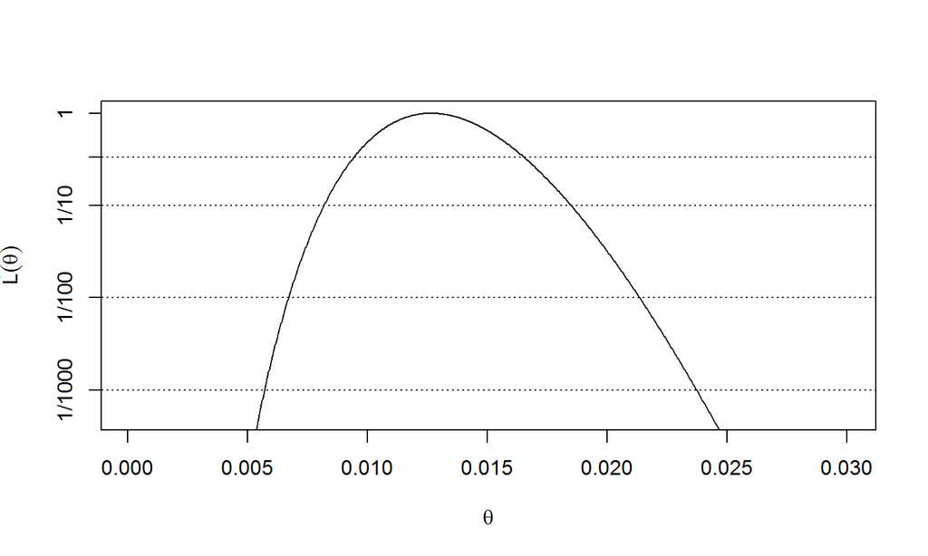

## Omparametrisering av modell

## Omparametrisering

**Definition:** En omparametrisering av en statistisk modell \(\mathcal{P}\) ges av en bijektion \(\phi=h(\theta)\) så att \[\mathcal{P}=\{P_\theta; \theta\in\Theta \}=\{Q_\phi; \phi\in\Phi \},\] där \(Q_{h(\theta)}=P_\theta\).

## Omparametrisering: Livslängder \(\mu=1/\theta\)

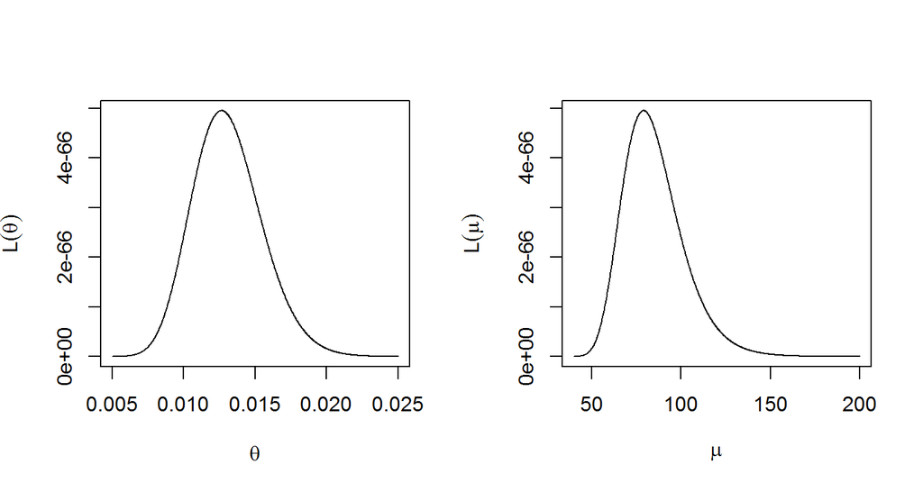

## Plug-in principen

**Definition:** (Plug-in principen) Givet en skattning av \(\hat{\theta}\) av \(\theta_0\) skattas \(\phi_0=h(\theta_0)\) med \(\hat{\phi}=h(\hat{\theta})\).

## Score och information

## Score och information

**Definition:** (H & B, def 2.6, 5.1) Score-funktionen till en deriverbar likelihood-funktion \(L\) av en variabel \(\theta\) är log-likelihoodfunktionens derivata \[ S(\theta)=\frac{d}{d\theta}\log L(\theta)=\frac{L'(\theta)}{L(\theta)}. \] Score-vektorn till en differentierbar likelihood-funktion av en vektorvärd parameter \(\theta=(\theta_1,\ldots,\theta_d)\) är log-likelihoodfunktionens gradient: \[ S(\theta)=\nabla\log L(\theta)=(\frac{d\log L(\theta)}{d\theta_1},\ldots,\frac{d\log L(\theta)}{d\theta_d}). \]

## Livslängder, score

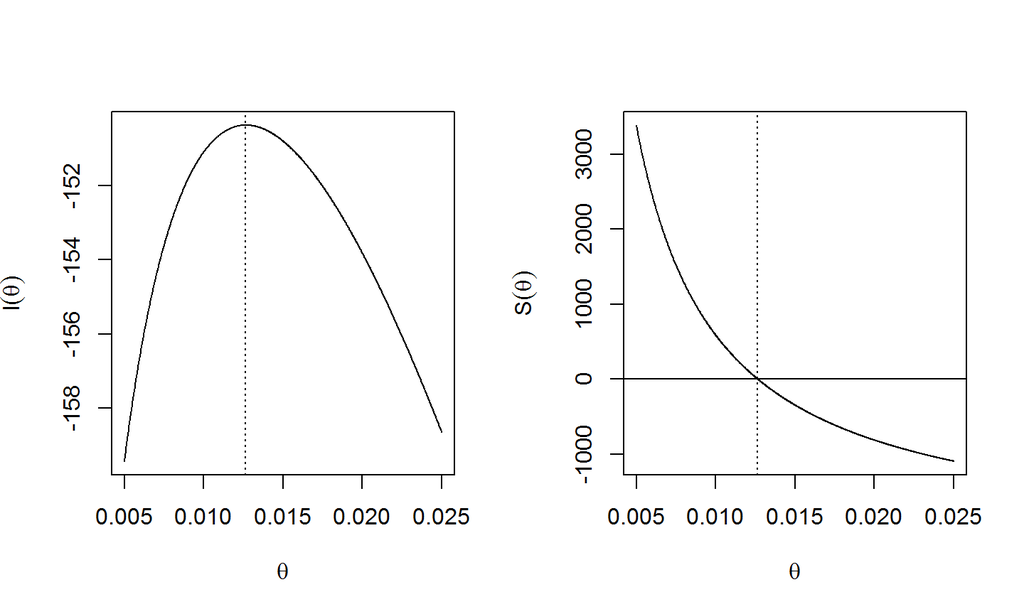

## Score och information

**Definition:** (H & B, def. 2.7, 5.3) Fisher-informationen till en två gånger deriverbar likelihood-funktion \(L\) av en variabel \(\theta\) är; \[ I(\theta)=-\frac{d^2}{d\theta^2}\log L(\theta)=-\frac{d}{d\theta} S(\theta). \] Fishers informationsmatris för en två gånger differentierbar likelihood-funktion av en vektorvärd parameter \(\theta=(\theta_1,\ldots,\theta_d)\) är; \[ I(\theta)=-Hess(\log L(\theta))=-\bigl(\frac{d^2}{d\theta_i\,d\theta_j}\log L(\theta)\bigr). \] Speciellt kallas \(I(\hat{\theta})\) den observerade Fisher-informationen.

## Observerad Fisherinformation efter omparametrisering

**Sats:** (H & B, res. 2.1) Låt \(\phi=h(\theta)\), \(\phi, \theta\in \mathbf{R}\) vara en omparametrisering. Då ges observerade Fisherinformationen i den nya parametriseringen av \[ I_\phi(\hat{\phi})=I_\theta(\hat{\theta})h'(\hat{\theta})^{-2} \]

## Numerik

## Approximation av log-likelihoodfunktion

**Taylorutveckling av ordning två: (H & B, B.2.3)** I en omgivning av \(x=a\) kan en två ggr kontinuerligt deriverbar funktion approximeras med \[ f(x)\approx f(a) + (x-a)f'(a) + \frac{(x-a)^2f''(a)}{2}. \]

## Approximation av log-likelihood och likelihood

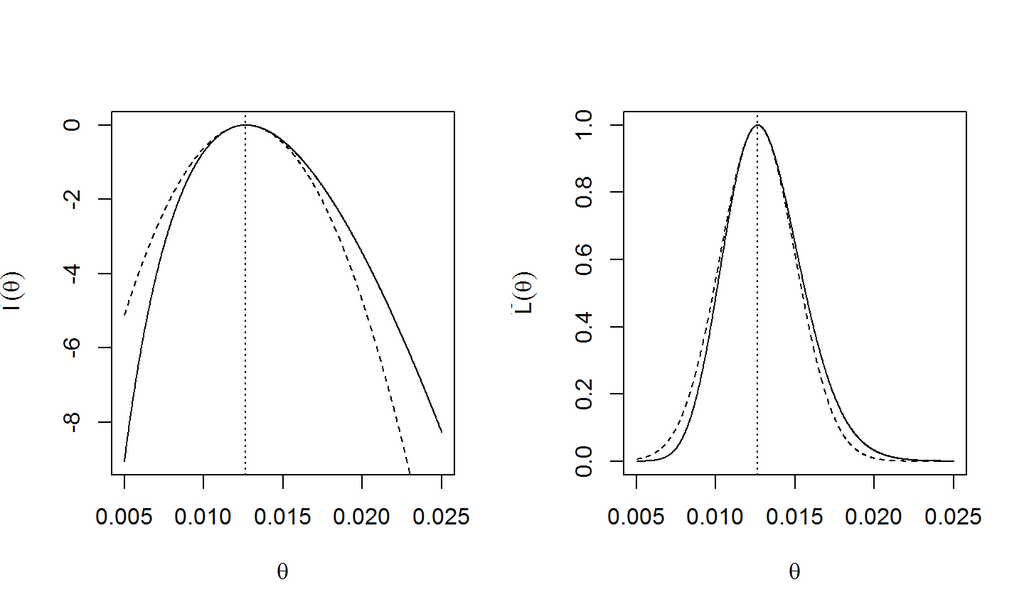

## Trädvolym

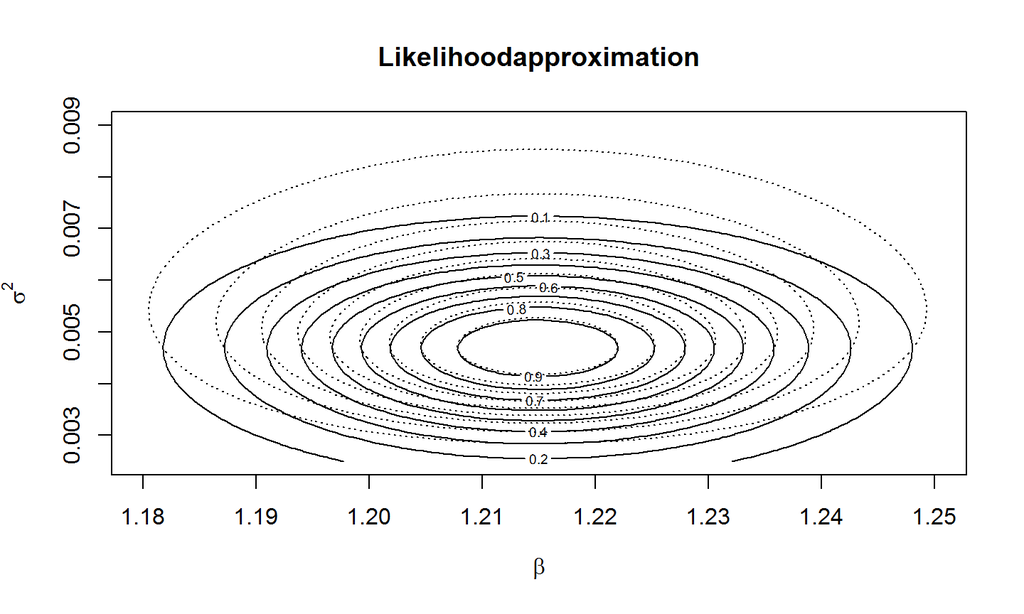

## Newton - Raphsons metod

**Newton-Raphsons metod:** (H & B, C.1.3)

- Välj startvärde \(x_0\).
- Iterera \[x_{n+1}=x_n-\frac{f'(x_n)}{f''(x_n)}\] tills \(|f'(x_n)|\) blir litet.

## Newton - Raphsons metod för livslängder

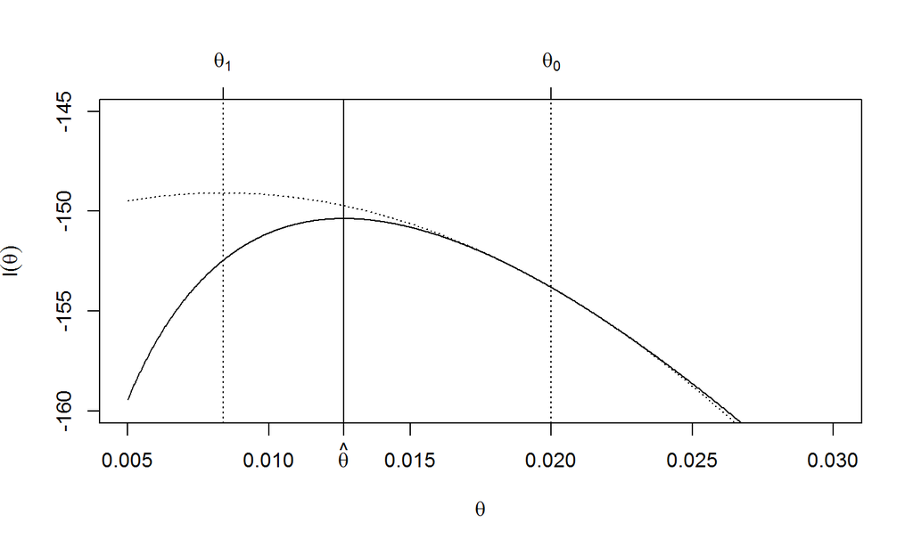

## Newton - Raphsons metod för livslängder

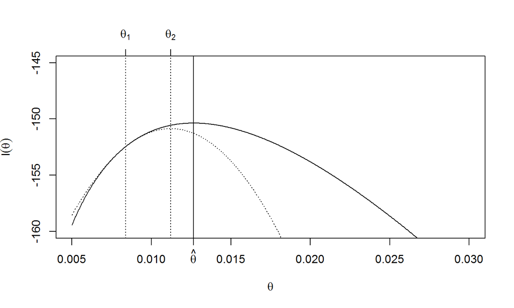

## Newton - Raphsons metod för livslängder

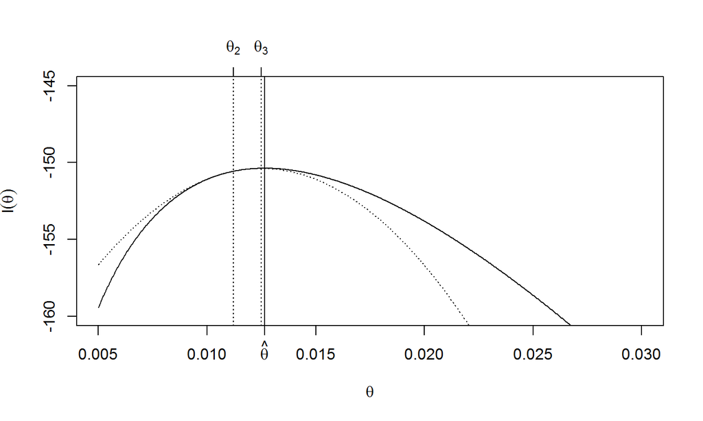

## Newton - Raphsons metod för livslängder

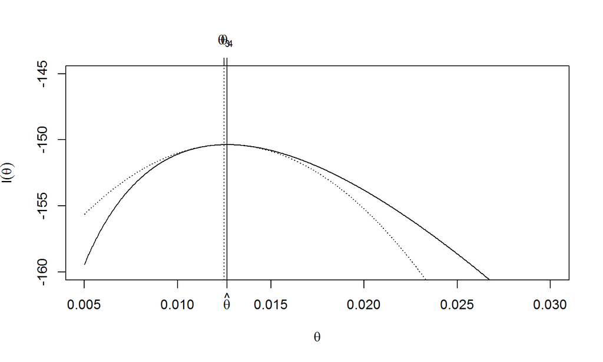

## Tillräcklighet

## Tillräcklighet

**Definition:** (Stickprovsvariabel (H & B, def 2.8))

En stickprovsvariabel är en funktion \(T=h(X)\) av ett stickprov med realisering \(t=h(x)\).

**Definition:** (Tillräcklighet (Sufficiency) (H & B, def 2.9))

En stickprovsvariabel \(t=h(x)\) är tillräcklig om fördelningen för \(X|T=t\), \(X\sim P_\theta\), ej beror på \(\theta\) för något \(t\).

## Tillräcklighet, faktoriseringskriteriet

**Sats:** (Faktoriseringskriteriet (H & B, Result 2.2))

En stickprovsvariabel \(T=h(X)\) är tillräcklig om och endast om tätheten/sannolikhetsfunktionen för \(X\) kan faktoriseras som \[ f_X(x|\theta)=g_1(h(x),\theta)g_2(x). \]

## Minimaltillräcklighet

**Definition:** (H & B, Definition 2.11) En stickprovsvariabel \(T=h(X)\) är minimaltillräcklig om den kan bestämmas ur varje annan till räcklig stickprovsvariabel \(\tilde{T}\).

## Två principer

## Tillräcklighetsprincipen och Likelihoodprincipen

**Tillräcklighetsprincipen:** Statistiska slutledningar skall endast bero på värdet av en tillräcklig stickprovsvariabel.

**Likelihoodprincipen:** Statistiska slutledningar skall endast bero på (relativa) likelihoodfunktionen.